# iFood CRM Data Analyst Case

# Objetivo

O objetivo da equipe é construir um modelo preditivo que irá produzir o maior lucro para o próxima campanha de marketing direto, prevista para o próximo mês. A nova campanha, visa vender um novo gadget para o banco de dados do cliente. Para construir o modelo, uma campanha piloto envolvendo 2.240 clientes foi realizada. Os clientes foram selecionados aleatoriamente e contatados por telefone sobre a aquisição do gadget. Durante os meses seguintes, os clientes que compraram o oferta foram devidamente rotuladas. A taxa de sucesso da campanha foi de 15%. O objetivo da equipe é desenvolver um modelo que preveja o comportamento do cliente e o aplique ao restante da base de clientes. Esperançosamente, o modelo permitirá que a empresa escolha os clientes com maior probabilidade de comprar a oferta, deixando de fora os não respondentes, tornando a próxima campanha altamente rentável. Além disso, além de maximizar o lucro da campanha, o CMO está interessado em compreensão para estudar as características dos clientes que estão dispostos a comprar o gadget.

- O conjunto de dados contém características sociodemográficas e firmográficas sobre 2.240 clientes que foram contatados. Além disso, ele contém uma bandeira para os clientes que responderam à campanha, comprando o produto.

# Cálculo RFM

```r
# valor gasto nos produtos
dados$mont <- dados$MntFishProducts+dados$MntFruits+dados$MntGoldProds+
              dados$MntMeatProducts+dados$MntSweetProducts+dados$MntWines

# quantidade de compras
dados$num <- dados$NumCatalogPurchases+dados$NumDealsPurchases+
             dados$NumStorePurchases+dados$NumWebPurchases

customers_RFM = sqldf(
    "SELECT ID,
            MIN(Recency) AS 'Recência',
            Sum(num) AS 'Frequência',
            SUM(mont) AS 'Monetariedade'
        FROM dados
        GROUP BY 1"
)

customers_RFM %>%
  head(10) %>%
      formattable::formattable()
```

| ID | Recência | Frequência | Monetariedade |
| --- | --- | --- | --- |
| 0 | 66 | 17 | 1198 |
| 1 | 0 | 18 | 577 |
| 9 | 86 | 11 | 120 |
| 13 | 57 | 6 | 32 |
| 17 | 81 | 28 | 1028 |
| 20 | 91 | 8 | 183 |
| 22 | 99 | 14 | 309 |
| 24 | 96 | 12 | 47 |
| 25 | 9 | 21 | 1115 |
| 35 | 35 | 10 | 210 |

# Histogramas

Para avaliar a distribuição dos parâmetros RFM podemos usar o histograma.

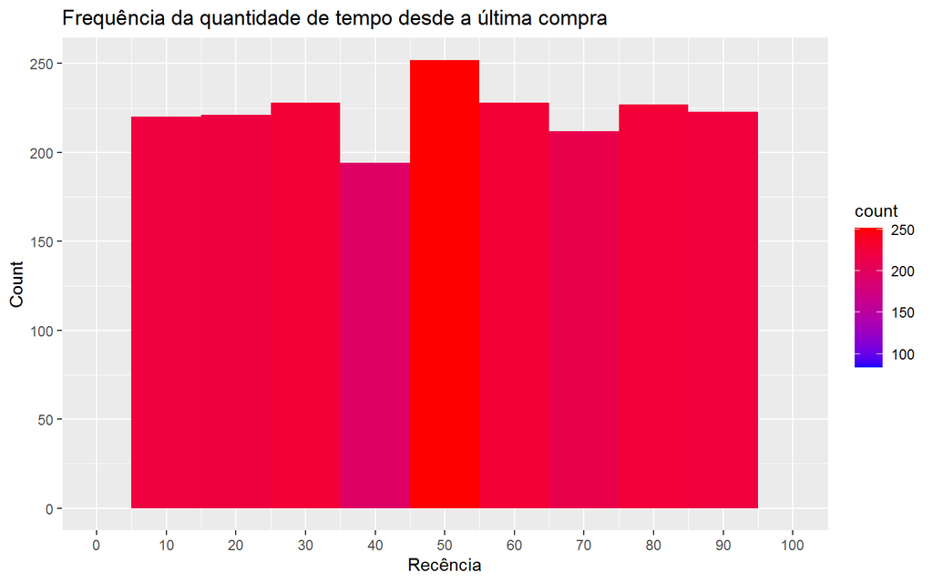

```r
# Recencia
ggplot(customers_RFM, aes(x = Recência)) +
        geom_histogram(aes(fill = ..count..), binwidth = 10) +
        scale_x_continuous(name = "Recência",
                           breaks = seq(0, 100, 10),
                           limits=c(0, 100)) +
        scale_y_continuous(name = "Count") +
        scale_fill_gradient(low="blue", high="red") +
        ggtitle("Frequência da quantidade de tempo desde a última compra")
```

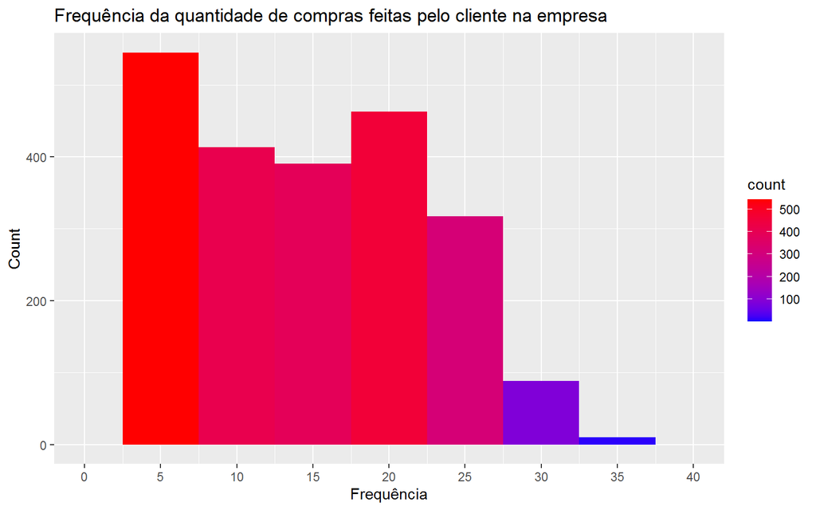

```r
# Frequencia
ggplot(customers_RFM, aes(x = Frequência)) +
        geom_histogram(aes(fill = ..count..), binwidth = 5) +
        scale_x_continuous(name = "Frequência",
                           breaks = seq(0, 40, 5),
                           limits=c(0, 40)) +
        scale_y_continuous(name = "Count") +
        scale_fill_gradient(low="blue", high="red") +
        ggtitle("Frequência da quantidade de compras feitas pelo cliente na empresa")
```

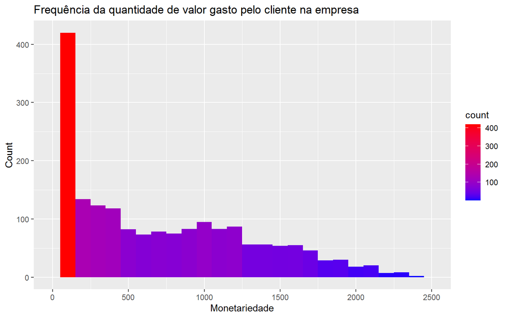

```r
# Monetariedade
ggplot(customers_RFM, aes(x = Monetariedade)) +
        geom_histogram(aes(fill = ..count..), binwidth = 100) +
        scale_x_continuous(name = "Monetariedade",
                           breaks = seq(0, 2500, 500),
                           limits=c(0, 2500)) +
        scale_y_continuous(name = "Count") +
        scale_fill_gradient(low="blue", high="red") +
        ggtitle("Frequência da quantidade de valor gasto pelo cliente na empresa")
```

# Percentil

```r
quantile(customers_RFM$Recência, probs = seq(0, 1, 0.20)) %>% pander()
```

| 0% | 20% | 40% | 60% | 80% | 100% |
| --- | --- | --- | --- | --- | --- |
| 0 | 19 | 39 | 59 | 79 | 99 |

Analisando a quantos dias foi a última compra do cliente, podemos observar que:

- Os Top20 clientes compraram nos últimos 19 dias;
- Os próximos 20% de clientes compraram no intervalo entre 19 e 39 dias;
- Ao passo que os últimos 20% de clientes ficam mais de 79 dias sem efetuar nenhuma compra.

```r
quantile(customers_RFM$Frequência, probs = seq(0, 1, 0.20)) %>% pander()
```

| 0% | 20% | 40% | 60% | 80% | 100% |
| --- | --- | --- | --- | --- | --- |
| 0 | 7 | 11 | 17 | 22 | 44 |

Quanto à frequência com que fazem as compras, podemos observar que:

- Os clientes Top20 compraram mais de 22 vezes ao longo do periódo em análise;
- Os seguintes 20% dos clientes compraram entre 17 e 22 vezes;
- Os últimos 20% dos clientes compraram 7 vezes no periódo em análise.

```r
quantile(customers_RFM$Monetariedade, probs = seq(0, 1, 0.20)) %>% pander()
```

| 0% | 20% | 40% | 60% | 80% | 100% |
| --- | --- | --- | --- | --- | --- |
| 5 | 55 | 194.6 | 635.4 | 1174 | 2525 |

Quanto ao valor gasto pelo cliente, podemos observar que:

- Os clientes Top20 gastam em média mais de 1174.00 u.m (unidade monetária);
- Os 20% seguintes gastam entre 635.4 e 1174.00 u.m, enquanto que os últimos 20% dos clientes gastam menos de 55.00 u.m em seu consumo médio.

# RFM score

```r
rfm_data <- customers_RFM

rfm_data <-
    rfm_data %>%
    mutate(
        R = ntile(desc(Recência), 5),
        F = ntile(Frequência, 5),
        M = ntile(Monetariedade, 5)
    )

rfm_data$RFM <- rfm_data$R * 100 + rfm_data$F * 10 + rfm_data$M

rfm_data %>%
  head(10) %>%
      formattable::formattable()
```

| ID | Recência | Frequência | Monetariedade | R | F | M | RFM |
| --- | --- | --- | --- | --- | --- | --- | --- |
| 0 | 66 | 17 | 1198 | 2 | 3 | 5 | 235 |
| 1 | 0 | 18 | 577 | 5 | 4 | 3 | 543 |
| 9 | 86 | 11 | 120 | 1 | 2 | 2 | 122 |
| 13 | 57 | 6 | 32 | 3 | 1 | 1 | 311 |
| 17 | 81 | 28 | 1028 | 1 | 5 | 4 | 154 |
| 20 | 91 | 8 | 183 | 1 | 2 | 2 | 122 |
| 22 | 99 | 14 | 309 | 1 | 3 | 3 | 133 |
| 24 | 96 | 12 | 47 | 1 | 3 | 1 | 131 |
| 25 | 9 | 21 | 1115 | 5 | 4 | 4 | 544 |
| 35 | 35 | 10 | 210 | 4 | 2 | 3 | 423 |

Note que, os clientes com elevado RFM score apresentam valores baixos para variável Recência e a altos para as variáveis Frequência e Monetariedade, por exemplo ID = 25, enquanto que os clientes com baixo RFM score, mostram altos valores para a variável Recência e altos para Frequência , como por exemplo ID = 17. Sendo que, para clientes com valores RFM score intermédios precisam de uma análise mais cuidadosa. Como será verificado a seguir.

# Segmentação de clientes

```r
rfm_data$segment <- NA

rfm_data$segment[which(rfm_data$RFM == 111)] <- 'Perdidos'
rfm_data$segment[which(rfm_data$RFM > 111)] <- 'Hibernando'

rfm_data$segment[which(rfm_data$RFM >= 222)] <- 'Prestes a hibernar'

rfm_data$segment[which(rfm_data$RFM >= 333)] <- 'Clientes em potencial'

rfm_data$segment[which(rfm_data$RFM >= 444)] <- 'Campeões'


# 2nd round
rfm_data$segment[which(rfm_data$segment == 'Clientes em potencial' &
                           (rfm_data$F >= 4))] <- 'Clientes fiéis'

rfm_data$segment[which(rfm_data$segment == 'Prestes a hibernar' &
                           (rfm_data$M >= 4))] <-'Precisa de atenção'

rfm_data$segment[which(rfm_data$segment == 'Hibernando' &
                           (rfm_data$F >= 4 & rfm_data$M >= 4))] <-'Não posso perdê-los'

rfm_data[, -c(5, 6,7)] %>%
    head(10) %>%
    formattable::formattable()
```

| ID | Recência | Frequência | Monetariedade | RFM | segment |
| --- | --- | --- | --- | --- | --- |
| 0 | 66 | 17 | 1198 | 235 | Precisa de atenção |
| 1 | 0 | 18 | 577 | 543 | Campeões |
| 9 | 86 | 11 | 120 | 122 | Hibernando |
| 13 | 57 | 6 | 32 | 311 | Prestes a hibernar |
| 17 | 81 | 28 | 1028 | 154 | Não posso perdê-los |
| 20 | 91 | 8 | 183 | 122 | Hibernando |
| 22 | 99 | 14 | 309 | 133 | Hibernando |
| 24 | 96 | 12 | 47 | 131 | Hibernando |
| 25 | 9 | 21 | 1115 | 544 | Campeões |
| 35 | 35 | 10 | 210 | 423 | Clientes em potencial |

# Distribuição dos clientes por segmentos

```r
rfm_data$segment <-
    factor(
        x = rfm_data$segment,
        levels = c(
            'Perdidos',
            'Hibernando',
            'Não posso perdê-los',
            'Prestes a hibernar',
            'Precisa de atenção',
            'Novos clientes',
            'Clientes em potencial',
            'Clientes fiéis',
            'Campeões'
        )
    )


# tabela frequencia
freqTable <-
    rfm_data %>%
    # group_by(group) %>%
    count(segment) %>%
    # arrange(desc(n)) %>%
    rename(Segment = segment, Count = n)

freqTable %>%
      formattable::formattable()
```

| Segment | Count |
| --- | --- |
| Perdidos | 68 |
| Hibernando | 322 |
| Não posso perdê-los | 156 |
| Prestes a hibernar | 351 |
| Precisa de atenção | 193 |
| Clientes em potencial | 345 |
| Clientes fiéis | 207 |
| Campeões | 598 |

```r
# ou agrupados
cust_aggr_dat <-
    aggregate(x = rfm_data[, 2:4],
              by = list(rfm_data$segment),
              mean)


cust_aggr_dat %>%
      formattable::formattable()
```

| Group.1 | Recência | Frequência | Monetariedade |
| --- | --- | --- | --- |
| Perdidos | 88.29412 | 4.852941 | 31.98529 |
| Hibernando | 83.49379 | 10.046584 | 236.57764 |
| Não posso perdê-los | 89.33974 | 23.192308 | 1252.18590 |
| Prestes a hibernar | 57.98006 | 10.034188 | 163.23077 |
| Precisa de atenção | 68.70984 | 21.119171 | 1272.25907 |
| Clientes em potencial | 33.21739 | 10.817391 | 357.40580 |
| Clientes fiéis | 47.41063 | 22.429952 | 1029.28986 |
| Campeões | 13.86789 | 16.948161 | 742.61873 |

Os resultados mostram que:

- Os clientes Campeões (598), considerados os clientes mais valiosos gastam em média o valor de 743.00 u.m, efetuaram compras por mais de 17 vezes e a última compra foi em média há 14 dias;
- Enquanto que, os Perdidos o caso pior estão há 88 dias sem efetuar uma compra;
- O destaque vai para o segmento Precisa de atenção, uma vez que apresentam um consumo elevado, contudo a última atividade foi há mais de 2 meses.

# Visualização dos dados

```r
# tree map
hctreemap2(
    data = freqTable,
    group_vars = "Segment",
    size_var = "Count",
    color_var = "Count"
    )
```

[interactive chart not shown]

```r
# grafico de barras
highchart() %>%
    hc_add_series(
        data = freqTable,
        type = 'column',
        hcaes(x = Segment, y = Count),
        dataLabels = list(align = "center", enabled = TRUE,
                          style = list(
                                      fontWeight = "bold",
                                      color = "#f7a35c",
                                      textOutline = NULL
                                      )
                          ),
        name = 'Segmentos'
    ) %>%
    hc_xAxis(categories = unique(freqTable$Segment)) %>%
    hc_yAxis(title = list(text = "Número de clientes"))
```

[interactive chart not shown]

Os clientes no segmento Campeões são considerados os mais valiosos e os Prestes a hibernar e Precisa de atenção, precisam de alguma atenção especial para os resgatar.

# Aplicando o algoritmo Naive Bayes

Escolhi o algoritmo de Naive Bayes, pois ele desconsidera correlações entre as variáveis, tratando cada variável de forma independente. Este algoritmo também é mais rápido para implementar do que por exemplo um algoritmo SVM e além de não precisar de muitos dados para fazer a classificação.

# Matriz de confusão

```r
# matriz confusao compara a base de teste com as previsoes
matriz_confusao = table(base_teste[, 25], previsoes)

# Percentual acertos
confusionMatrix(matriz_confusao)
```

```
## Confusion Matrix and Statistics
##
##    previsoes
##       0   1
##   0 449  22
##   1  16  67
##
##                Accuracy : 0.9314
##                  95% CI : (0.9071, 0.951)
##     No Information Rate : 0.8394
##     P-Value [Acc > NIR] : 5.688e-11
##
##                   Kappa : 0.7385
##
##  Mcnemar's Test P-Value : 0.4173
##
##             Sensitivity : 0.9656
##             Specificity : 0.7528
##          Pos Pred Value : 0.9533
##          Neg Pred Value : 0.8072
##              Prevalence : 0.8394
##          Detection Rate : 0.8105
##    Detection Prevalence : 0.8502
##       Balanced Accuracy : 0.8592
##
##        'Positive' Class : 0
##
```

Analisando a matriz de confusâo, na classe 0 (cliente não comprou a oferta) o algoritmo classificou corretamente 449 observações e incorretamente 22 observações, na classe 1 (cliente comprou a oferta) o algoritmo classificou corretamente 67 observações e incorretamente 16 observações. Nas duas classes o algoritmo acertou mais do que errou.

O percentual de acerto do modelo foi de 93,14%.

# Fazendo previsões

```r
dados[, -c(2:25)] %>%
    head(28) %>%
   pander()
```

|  | ID | Response | previsoes |
| --- | --- | --- | --- |
| **1** | 5524 | 1 | 0 |
| **2** | 2174 | 0 | 0 |
| **3** | 4141 | 0 | 0 |
| **4** | 6182 | 0 | 0 |
| **5** | 5324 | 0 | 0 |
| **6** | 7446 | 0 | 0 |
| **7** | 965 | 0 | 0 |
| **8** | 6177 | 0 | 0 |
| **9** | 4855 | 1 | 0 |
| **10** | 5899 | 0 | 0 |
| **12** | 387 | 0 | 0 |
| **13** | 2125 | 0 | 0 |
| **14** | 8180 | 0 | 1 |
| **15** | 2569 | 0 | 0 |
| **16** | 2114 | 1 | 0 |
| **17** | 9736 | 0 | 0 |
| **18** | 4939 | 0 | 0 |
| **19** | 6565 | 0 | 0 |
| **20** | 2278 | 0 | 1 |
| **21** | 9360 | 0 | 0 |
| **22** | 5376 | 0 | 0 |
| **23** | 1993 | 0 | 0 |
| **24** | 4047 | 0 | 0 |
| **25** | 1409 | 0 | 0 |
| **26** | 7892 | 0 | 0 |
| **27** | 2404 | 0 | 0 |
| **29** | 9422 | 0 | 0 |
| **30** | 1966 | 0 | 1 |